# PROJECT

# We can draw a graph taht shows the predicted probabilities that each patient has heart disease along with their actual heart disease status.

# 1. To draw the graph, we start by creating a new data.frame that contains the probabilities of having heart disease along with the actual hear disease status.

# 2. Then we sort the data.frame from low probabilities to high probabilities.

# 3. Then we add a new column to the data.frame that has the rank of each sample, from low probability to high probability.

```r
# Creating data-frame

predicted_data <- data.frame(probability.of.target=logistic1$fitted.values, target=train_data$target)
```

```r
# Sorting

predicted_data <- predicted_data[order(predicted_data$probability.of.target, decreasing = FALSE),]
```

```r
predicted_data$rank <- 1:nrow(predicted_data)
```

```r
# predicted_data
```

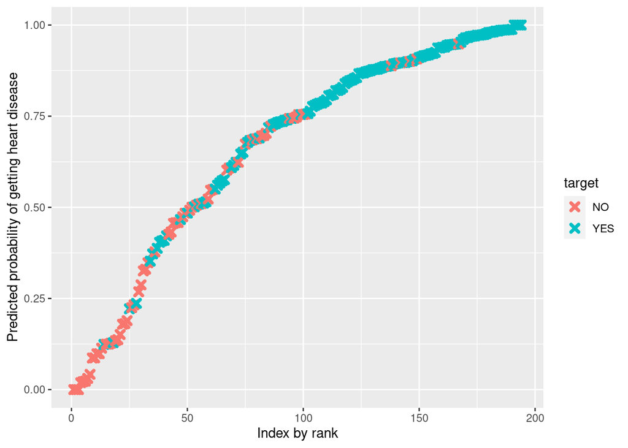

```r
ggplot(data=predicted_data, aes(x=rank, y=probability.of.target)) +
  geom_point(aes(color=target), alpha=1, shape=4, stroke=2) +
  xlab("Index by rank") +
  ylab("Predicted probability of getting heart disease")
```

# The above graph shows the predicted probabilities of whether a patient has heart disease or not, along with their actual heart disease status.

# The ‘Index by rank’ label on the x-axix gives the position/rank of the given data point in the sorted data-frame, which is being plotted here along with tha probabilities.

# Most of the people with heart disease (ones in blue), are predicted to have a high probability of having a heart disease.

# Most of the people without heart disease (ones in red), are predicted to have low probability of having a heart disease.

# Thus, it can be said that our Logistic Regression Model has worked successfully well.

```r
#nrow(train_data)
```

```r
res <- predict(logistic1,test_data,type="response")
res
```

[output not shown]

```r
res1 <- predict(logistic1,train_data,type="response")
res1
```

[output not shown]

[output cut: 11 more lines]

[output not shown]

```r
confmatrix1 <- table(Actual_value=train_data$target, predicted_value = res1 >0.5 )
confmatrix1
```

```
##             predicted_value
## Actual_value FALSE TRUE
##          NO     38   27
##          YES    13  116
```

```r
confmatrix <- table(Actual_value=test_data$target, predicted_value = res >0.5 )
confmatrix
```

```
##             predicted_value
## Actual_value FALSE TRUE
##          NO     17   12
##          YES    20   60
```

```r
#ACCURACY
(confmatrix1[[1,1]] + confmatrix1[[2,2]]) / sum(confmatrix1)*100
```

```
## [1] 79.38144
```